# Homework 5 - Optimization

Shuang Du

2/20/2022

# Question 1: Simple Univariate Optimization

Use Newton-Raphson to maximize the following function:
$$f(x) = 7\log(x) + 3\log(1-x).$$
Fill in the R functions below pertaining to $f(x)$, $f'(x)$ and $f''(x)$. Utilize the values below to initialize and run the algorithm (analogous to how they were defined in class). Repeat the method for several starting values for $x$ given below, picking the best $\hat{x}$ in terms of the final objective function value for each. Make sure you print your final value for $\hat{x}$

```r
# f(x)
f = function(x){
  value = 7*log(x) + 3*log(1-x)
  return(value)
}
# first derivative
f1 = function(x){
  first = 7*x^(-1)-3*(1-x)^(-1)
  return(first)
}
# second derivative
f2 = function(x){
  second = -7*x^(-2) - 3*(1-x)^(-2)
  return(second)
}

# initial value: x = 0.01
tol = 10^-4
x = 0.01
maxit = 50
iter = 0
eps = Inf
while (eps > tol & iter < maxit) {
  x0 = x
  h = -f1(x) / f2(x)
  x = x + h
  fval = f(x)
  eps  = abs(x - x0)
  iter = iter + 1
  if (iter == maxit)
    warning("Iteration limit reached without convergence")
  cat(sprintf("Iter: %d function: %f x: %f h: %f eps:%f\n", iter, fval, x, h, eps))
}
```

```
## Iter: 1 function: -27.459956 x: 0.019956 h: 0.009956 eps:0.009956
## Iter: 2 function: -22.700319 x: 0.039735 h: 0.019779 eps:0.019779
## Iter: 3 function: -18.037568 x: 0.078736 h: 0.039002 eps:0.039002
## Iter: 4 function: -13.582581 x: 0.154352 h: 0.075616 eps:0.075616
## Iter: 5 function: -9.601393 x: 0.294627 h: 0.140275 eps:0.140275
## Iter: 6 function: -6.781661 x: 0.519686 h: 0.225058 eps:0.225058
## Iter: 7 function: -6.109311 x: 0.705278 h: 0.185593 eps:0.185593
## Iter: 8 function: -6.108643 x: 0.700054 h: -0.005224 eps:0.005224
## Iter: 9 function: -6.108643 x: 0.700000 h: -0.000054 eps:0.000054
```

```r
# initial value: x = 0.5
tol = 10^-4
x = 0.5
maxit = 50
iter = 0
eps = Inf
while (eps > tol & iter < maxit) {
  x0 = x
  h = -f1(x) / f2(x)
  x = x + h
  fval = f(x)
  eps  = abs(x - x0)
  iter = iter + 1
  if (iter == maxit)
    warning("Iteration limit reached without convergence")
  cat(sprintf("Iter: %d function: %f x: %f h: %f eps:%f\n", iter, fval, x, h, eps))
}
```

```
## Iter: 1 function: -6.108643 x: 0.700000 h: 0.200000 eps:0.200000
## Iter: 2 function: -6.108643 x: 0.700000 h: 0.000000 eps:0.000000
```

```r
# initial value: x = 0.99
tol = 10^-4
x = 0.99
maxit = 50
iter = 0
eps = Inf
while (eps > tol & iter < maxit) {
  x0 = x
  h = -f1(x) / f2(x)
  x = x + h
  fval = f(x)
  eps  = abs(x - x0)
  iter = iter + 1
  if (iter == maxit)
    warning("Iteration limit reached without convergence")
  cat(sprintf("Iter: %d function: %f x: %f h: %f eps:%f\n", iter, fval, x, h, eps))
}
```

```
## Iter: 1 function: -11.911704 x: 0.980238 h: -0.009762 eps:0.009762
## Iter: 2 function: -10.040717 x: 0.961423 h: -0.018815 eps:0.018815
## Iter: 3 function: -8.368778 x: 0.926590 h: -0.034834 eps:0.034834
## Iter: 4 function: -7.060153 x: 0.867614 h: -0.058976 eps:0.058976
## Iter: 5 function: -6.314806 x: 0.786754 h: -0.080859 eps:0.080859
## Iter: 6 function: -6.118271 x: 0.719843 h: -0.066911 eps:0.066911
## Iter: 7 function: -6.108659 x: 0.700823 h: -0.019020 eps:0.019020
## Iter: 8 function: -6.108643 x: 0.700001 h: -0.000822 eps:0.000822
## Iter: 9 function: -6.108643 x: 0.700000 h: -0.000001 eps:0.000001
```

The above results show that the $\hat{x}$ is 0.7 no matter what initial value of x is taken.

Bonus: $f(x)$ pertains to the likelihood/PDF for which distribution(s)? Two answers are possible. Given this, what would be a closed form estimate for $\hat{x}$?

$f(x)$ pertains to the likelihood of binomial distribution where $n=10$ and $y=7$. $n$ represents the number of trials and $y$ represents success times. A closed form estimate for $\hat{x}$ would be $\hat{x} = \frac{7}{10} = 0.7$, which aligns with the result from Newton-Raphson Method.

# Question 2: Not So Simple Univariate Optimization

Repeat question 1 for the function below, using the same template for your answer. Choose a range of starting values between 0 and 5 and report the best $\hat{x}$ based on the final objective function value:

$$f(x) = 1.95 - e^{-2/x} - 2e^{-x^4}.$$

```r
# f(x)
f = function(x){
  value = 1.95 - exp(-2/x) - 2*exp(-x^4)
  return(value)
}

# first derivative
f1 = function(x){
  first = exp(-2/x)*(-2)*x^(-2) + 8*exp(-x^4)*x^3
  return (first)
}

# second derivative
f2 = function(x){
  second = 8*(-4*exp(-x^4)*x^6 + 3*exp(-x^4)*x^2) - 2*(2*exp(-2/x)-2*exp(-2/x)*x)/(x^4)
  return (second)
}

# to start the model
tol = 10^-4
x = 1.2 # also try 0.5 and 0.99
maxit = 50
iter = 0
eps = Inf
while (eps > tol & iter < maxit) {
  x0 = x
  h = -f1(x) / f2(x)
  x = x + h
  fval = f(x)
  eps  = abs(x - x0)
  iter = iter + 1
  if (iter == maxit)
    warning("Iteration limit reached without convergence")
  cat(sprintf("Iter: %d function: %f x: %f h: %f eps:%f\n", iter, fval, x, h, eps))
}
```

```
## Iter: 1 function: 1.666071 x: 1.394293 h: 0.194293 eps:0.194293
## Iter: 2 function: 1.674375 x: 1.453782 h: 0.059489 eps:0.059489
## Iter: 3 function: 1.674724 x: 1.469294 h: 0.015513 eps:0.015513
## Iter: 4 function: 1.674725 x: 1.470353 h: 0.001059 eps:0.001059
## Iter: 5 function: 1.674725 x: 1.470358 h: 0.000005 eps:0.000005
```

```r
# to start the model
tol = 10^-4
x = 0.5 # also try 0.5 and 0.99
maxit = 50
iter = 0
eps = Inf
while (eps > tol & iter < maxit) {
  x0 = x
  h = -f1(x) / f2(x)
  x = x + h
  fval = f(x)
  eps  = abs(x - x0)
  iter = iter + 1
  if (iter == maxit)
    warning("Iteration limit reached without convergence")
  cat(sprintf("Iter: %d function: %f x: %f h: %f eps:%f\n", iter, fval, x, h, eps))
}
```

```
## Iter: 1 function: -0.029492 x: 0.326906 h: -0.173094 eps:0.173094
## Iter: 2 function: -0.046324 x: 0.208041 h: -0.118864 eps:0.118864
## Iter: 3 function: -0.049368 x: 0.133345 h: -0.074697 eps:0.074697
## Iter: 4 function: -0.049877 x: 0.088606 h: -0.044739 eps:0.044739
## Iter: 5 function: -0.049976 x: 0.059067 h: -0.029539 eps:0.029539
## Iter: 6 function: -0.049995 x: 0.039378 h: -0.019689 eps:0.019689
## Iter: 7 function: -0.049999 x: 0.026252 h: -0.013126 eps:0.013126
## Iter: 8 function: -0.050000 x: 0.017501 h: -0.008751 eps:0.008751
## Iter: 9 function: -0.050000 x: 0.011667 h: -0.005834 eps:0.005834
## Iter: 10 function: -0.050000 x: 0.007778 h: -0.003889 eps:0.003889
## Iter: 11 function: -0.050000 x: 0.005186 h: -0.002593 eps:0.002593
## Iter: 12 function: -0.050000 x: 0.003457 h: -0.001729 eps:0.001729
## Iter: 13 function: -0.050000 x: 0.002305 h: -0.001152 eps:0.001152
## Iter: 14 function: -0.050000 x: 0.001536 h: -0.000768 eps:0.000768
## Iter: 15 function: -0.050000 x: 0.001024 h: -0.000512 eps:0.000512
## Iter: 16 function: -0.050000 x: 0.000683 h: -0.000341 eps:0.000341
## Iter: 17 function: -0.050000 x: 0.000455 h: -0.000228 eps:0.000228
## Iter: 18 function: -0.050000 x: 0.000303 h: -0.000152 eps:0.000152
## Iter: 19 function: -0.050000 x: 0.000202 h: -0.000101 eps:0.000101
## Iter: 20 function: -0.050000 x: 0.000135 h: -0.000067 eps:0.000067
```

```r
# to start the model
tol = 10^-4
x = 0.99 # also try 0.5 and 0.99
maxit = 50
iter = 0
eps = Inf
while (eps > tol & iter < maxit) {
  x0 = x
  h = -f1(x) / f2(x)
  x = x + h
  fval = f(x)
  eps  = abs(x - x0)
  iter = iter + 1
  if (iter == maxit)
    warning("Iteration limit reached without convergence")
  cat(sprintf("Iter: %d function: %f x: %f h: %f eps:%f\n", iter, fval, x, h, eps))
}
```

```
## Iter: 1 function: 1.571994 x: 2.055827 h: 1.065827 eps:1.065827
## Iter: 2 function: 1.339105 x: 4.058195 h: 2.002368 eps:2.002368
## Iter: 3 function: 1.206407 x: 6.750788 h: 2.692593 eps:2.692593
## Iter: 4 function: 1.120296 x: 10.713127 h: 3.962339 eps:3.962339
## Iter: 5 function: 1.063371 x: 16.621167 h: 5.908040 eps:5.908040
## Iter: 6 function: 1.025538 x: 25.463759 h: 8.842591 eps:8.842591
## Iter: 7 function: 1.000347 x: 38.716076 h: 13.252318 eps:13.252318
## Iter: 8 function: 0.983561 x: 58.587372 h: 19.871295 eps:19.871295
## Iter: 9 function: 0.972373 x: 88.389740 h: 29.802368 eps:29.802368
## Iter: 10 function: 0.964915 x: 133.090331 h: 44.700591 eps:44.700591
## Iter: 11 function: 0.959943 x: 200.139282 h: 67.048951 eps:67.048951
## Iter: 12 function: 0.956629 x: 300.711434 h: 100.572152 eps:100.572152
## Iter: 13 function: 0.954419 x: 451.568819 h: 150.857385 eps:150.857385
## Iter: 14 function: 0.952946 x: 677.854338 h: 226.285519 eps:226.285519
## Iter: 15 function: 0.951964 x: 1017.282246 h: 339.427908 eps:339.427908
## Iter: 16 function: 0.951309 x: 1526.423860 h: 509.141615 eps:509.141615
## Iter: 17 function: 0.950873 x: 2290.136118 h: 763.712258 eps:763.712258
## Iter: 18 function: 0.950582 x: 3435.704396 h: 1145.568278 eps:1145.568278
## Iter: 19 function: 0.950388 x: 5154.056739 h: 1718.352344 eps:1718.352344
## Iter: 20 function: 0.950259 x: 7731.585206 h: 2577.528467 eps:2577.528467
## Iter: 21 function: 0.950172 x: 11597.877874 h: 3866.292668 eps:3866.292668
## Iter: 22 function: 0.950115 x: 17397.316854 h: 5799.438980 eps:5799.438980
## Iter: 23 function: 0.950077 x: 26096.475310 h: 8699.158456 eps:8699.158456
## Iter: 24 function: 0.950051 x: 39145.212984 h: 13048.737674 eps:13048.737674
## Iter: 25 function: 0.950034 x: 58718.319489 h: 19573.106505 eps:19573.106505
## Iter: 26 function: 0.950023 x: 88077.979242 h: 29359.659753 eps:29359.659753
## Iter: 27 function: 0.950015 x: 132117.468869 h: 44039.489627 eps:44039.489627
## Iter: 28 function: 0.950010 x: 198176.703307 h: 66059.234438 eps:66059.234438
## Iter: 29 function: 0.950007 x: 297265.554964 h: 99088.851656 eps:99088.851656
## Iter: 30 function: 0.950004 x: 445898.832447 h: 148633.277483 eps:148633.277483
## Iter: 31 function: 0.950003 x: 668848.748672 h: 222949.916225 eps:222949.916225
## Iter: 32 function: 0.950002 x: 1003273.623008 h: 334424.874337 eps:334424.874337
## Iter: 33 function: 0.950001 x: 1504910.934513 h: 501637.311505 eps:501637.311505
## Iter: 34 function: 0.950001 x: 2257366.901770 h: 752455.967257 eps:752455.967257
## Iter: 35 function: 0.950001 x: 3386050.852655 h: 1128683.950885 eps:1128683.950885
## Iter: 36 function: 0.950000 x: 5079076.778983 h: 1693025.926328 eps:1693025.926328
## Iter: 37 function: 0.950000 x: 7618615.668474 h: 2539538.889491 eps:2539538.889491
## Iter: 38 function: 0.950000 x: 11427924.002711 h: 3809308.334237 eps:3809308.334237
## Iter: 39 function: 0.950000 x: 17141886.504066 h: 5713962.501356 eps:5713962.501356
## Iter: 40 function: 0.950000 x: 25712830.256100 h: 8570943.752033 eps:8570943.752033
## Iter: 41 function: 0.950000 x: 38569245.884149 h: 12856415.628050 eps:12856415.628050
## Iter: 42 function: 0.950000 x: 57853869.326224 h: 19284623.442075 eps:19284623.442075
## Iter: 43 function: 0.950000 x: 86780804.489336 h: 28926935.163112 eps:28926935.163112
## Iter: 44 function: 0.950000 x: 130171207.234005 h: 43390402.744668 eps:43390402.744668
## Iter: 45 function: 0.950000 x: 195256811.351007 h: 65085604.117002 eps:65085604.117002
## Iter: 46 function: 0.950000 x: 292885217.526510 h: 97628406.175503 eps:97628406.175503
## Iter: 47 function: 0.950000 x: 439327826.789766 h: 146442609.263255 eps:146442609.263255
## Iter: 48 function: 0.950000 x: 658991740.684648 h: 219663913.894883 eps:219663913.894883
## Iter: 49 function: 0.950000 x: 988487611.526973 h: 329495870.842324 eps:329495870.842324
```

```
## Iter: 50 function: 0.950000 x: 1482731417.790459 h: 494243806.263486 eps:494243806.263486
```

What does this say about the stability of NR, especially in this case? Plot the second derivative of this function and comment on why or why this is supports your observations.

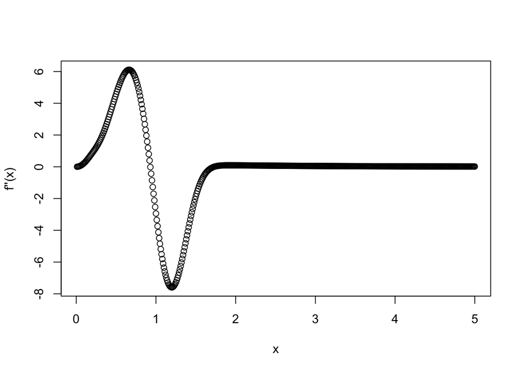

```r
plot(c(1:500)*0.01, f2(c(1:500)*0.01), xlab="x", ylab="f''(x)")
```

The above results show that the best $\hat{x}$ is 1.47 The plot shows that the optimization using NR method is unstable since the final output is highly sensitive to the original value of `x`. When `f''(x) < 0`, the original function is a concave function; when `f''(x) > 0`, the original function is a convex function. In the [1,5] interval, there exists x where `f''(x) = 0`, which have influenced the optimization using NR method.

## Multivariate optimization: Zero-inflated Poisson

Following a chemical spill from a local industrial plant, the city government is attempting to characterize the impact of the spill on recreational fishing at a nearby lake. Over the course of one month following the spill, park rangers asked each adult leaving the park how many fish they had caught that day. At the end of the month they had collected responses for 4,075 individuals, where the number of fish caught for each individual is summarized in the table below:

| 0 | 1 | 2 | 3 | 4 | 5 | 6 |
| --- | --- | --- | --- | --- | --- | --- |
| 3062 | 587 | 284 | 103 | 33 | 4 | 2 |

Based on an initial examination of this distribution, there appears to be many more zeros than expected. Upon speaking to the park rangers, they were embarrassed to state that after recording the number of fish each adult had caught, they did not ask or record whether each adult had gone to the park with the intention of fishing in the first place.

The city statistician surmised that the observed distribution in the table above may be resulting from a mixture of two populations of subjects. The first population pertains to the subset of visitors that arrived without any intention of fishing (exactly zero fish caught by each member of this population). The second population pertains to the set of visitors that arrived with the intention of fishing (0 or more fish potentially caught in this population). Therefore, if we fit a standard Poisson model to this data, the estimate for $\lambda$ would be biased downwards.

To account for the excess zeros in the observed data, the statistician decided to fit a zero-inflated Poisson model. To simplify things the log likelihood is given below, and we utilized the tabulated values from the table above in place of individual observations:

$$\mathcal{l}(\boldsymbol{\theta}) = n_0\log(\pi + (1-\pi)e^{-\lambda}) + (N-n_0)[\log(1-\pi) - \lambda] + \sum_{i=1}^{\infty}in_i\log(\lambda)$$

where $\boldsymbol{\theta} = (\pi, \lambda)$, $n_i$ pertains to the number of individuals that caught $i$ fish ($n_i=0$ for $i>6$ here), $N = 4075$, $\pi$ is the probability that an individual did not show up to fish, and $\lambda$ is the mean number of fish caught by those individuals that intended to fish at the park. From this log-likelihood, we can see that for the individuals that caught 0 fish, we assume those observations come from a mixture of individuals that did not show up to fish ($\pi$ proportion of the time) and those that showed up to fish but did not catch anything ($1-\pi$ proportion of the time with 0 for their catch count). The remaining individuals that caught more than zero fish are also in the log likelihood and are similarly weighted by $(1-\pi)$.

Lets go ahead and fit this model with Newton-Raphson. Similar to the previous problems, fill in the code below to fit this model. Then, fill in the function for the log likelihood and its 1st derivative
$$\left(\frac{\partial\mathcal{l}(\boldsymbol{\theta})}{\partial\pi}, \frac{\partial\mathcal{l}(\boldsymbol{\theta})}{\partial\lambda}\right)$$
and second derivative matrix

$$\left[\begin{array}
{rr}
\frac{\partial^2\mathcal{l}(\boldsymbol{\theta})}{\partial\pi^2} & \frac{\partial^2\mathcal{l}(\boldsymbol{\theta})}{\partial\pi \partial\lambda} \\
\frac{\partial^2\mathcal{l}(\boldsymbol{\theta})}{\partial\lambda \partial\pi } & \frac{\partial^2\mathcal{l}(\boldsymbol{\theta})}{\partial\lambda^2}
\end{array}\right]$$

Given the estimates, interpret the results. Accounting for the excess zeros, on average how many fish were caught among those who intended to go fishing? What proportion of subjects did not even consider to fish?

```r
# f(x)
logLik = function(theta, y, ny){
  ## solution
  value = ny[1]*log(theta[1] + (1-theta[1])*exp(-theta[2]))
                    +(sum(ny)-ny[1])*(log(1-theta[1]) - theta[2])
                    +sum(ny*y)*log(theta[2])
  return (value)
  # returns scalar
  ## end solution
}

# first derivative
f1 = function(theta,y, ny){
  N = sum(ny)
  n0 = ny[1]
  pi = theta[1]
  lambda = theta[2]
  ini = sum(ny*y)

  first1 = (-N*pi + N*exp(-lambda)*pi +n0
            -N*exp(-lambda))/((-pi+1)*(pi+exp(-lambda)*(-pi+1)))
  first2 = -(n0*exp(-lambda)*(-pi
            +1))/(pi+exp(-lambda)*(1-pi)) - N + n0 + ini/lambda
  return(as.matrix(c(first1, first2), nrow=2))
  # returns 2x1 vector
}

# second derivative
f2 = function(theta,y, ny){
  N = sum(ny)
  n0 = ny[1]
  pi = theta[1]
  lambda = theta[2]
  ini = sum(ny*y)

  second11 = -(n0*(-exp(-lambda)+1)^2)/((pi+exp(-lambda)*(1-pi))^2) - (N-n0)/((1-pi)^2)
  second12 = (n0*exp(-lambda))/((pi + exp(-lambda)*(-pi + 1))^2)
  second22 = (n0*exp(-lambda)*pi*(-pi+1))/((pi+exp(-lambda)*(-pi+1))^2) - ini/(lambda^2)
  return(matrix(c(second11, second12, second12, second22), nrow=2))
  # returns 2x2 matrix
}

# data
y = 0:6
ny = c(3062, 587, 284, 103, 33, 4, 2)

# to start the model
tol = 10^-4
theta = c(
          ny[y==0]/sum(ny), # initial value for pi, prop of total 0's
          sum(ny*y)/sum(ny) # initial value for lambda, mean of y's
          )
maxit = 50
iter = 0
eps = Inf
start = Sys.time()

while (eps > tol & iter < maxit) {
  theta0 = theta
  h = -solve(f2(theta, y, ny)) %*% f1(theta, y, ny)
  theta = theta + h
  logL = logLik(theta, y, ny)
  eps  = sqrt(sum((theta - theta0) ^ 2))
  iter = iter + 1
  if (iter == maxit)
    warning("Iteration limit reached without convergence")
  cat(
    sprintf(
      "Iter: %d logL: %.2f pi: %.3f lambda: %.3f eps:%f\n",
      iter,
      logL,
      theta[1],
      theta[2],
      eps
    )
  )
}
```

```
## Iter: 1 logL: -615.36 pi: 0.606 lambda: 0.620 eps:0.264339
## Iter: 2 logL: -866.16 pi: 0.557 lambda: 0.812 eps:0.197583
## Iter: 3 logL: -847.69 pi: 0.615 lambda: 0.988 eps:0.185752
## Iter: 4 logL: -874.78 pi: 0.614 lambda: 1.034 eps:0.045425
## Iter: 5 logL: -875.12 pi: 0.615 lambda: 1.038 eps:0.004334
## Iter: 6 logL: -875.13 pi: 0.615 lambda: 1.038 eps:0.000019
```

Based on the above result, we can conclude that 61.5% of the subjects did not consider to fish, and for the remaining subjects who intended to go fishing, the number of fish caught follows a Poisson distribution with a mean of 1.038. Therefore, on average 1.038 fish were caught among those who intended to go fishing.